# Envinformatics - Second Brain

Zettelkasten

Zotero

Obsidian

Zettelkasten Workflow using Zotero + Obsidian

Author

Me

Published

July 9, 2023

Implementing `Zettelkasten` workflow in reading, writing, note-taking, research method, creativity, brainstorming, idea generator, etc., using `Zotero` as a reference manager, and `Obsidian` as a note-taking app for references downloaded in Zotero. There is a whole religion around note-taking with concepts such as `Second Brain`, `Personal Knowledge Management (PKM)`, and Zettelkasten.

I find that a bit too much but I enjoy the software, it saves everything in clean `.md` files in your file system (makes it future-proof, you can change software later on and still have all your notes) and supports wiki-style linking between notes. I use Zotero simply because it is the best reference manager I have found, it is also free and open source if you are into that.

My workflow is such that I start by reading an article in my Zotero library, and make highlights and notes directly on the PDF in the app. I do this on the official app, phone, or computer. I then import these highlights and notes into obsidian for storage and further processing ([src](https://www.arslonga.email/how-to-connect-zotero-with-obsidian/)).

There are four parts to the zettelkasten method, and I summarize them here.

```
1- Capture
2- Organize
3- Connect
4- Emergence
```

**Capture**

Capturing is simple. There’s only one step

```
- Jot it down
```

Unformed ideas and potentially useful knowledge and information float around us all day long. So by capturing the idea, you save it for a later time when you can sit down, think it through, and see how it fits with the rest of your life.

**Organize**

Organizing is the second step of the zettelkasten method. It is when you take the time to analyze the things you captured. Many of those captures will need to be deleted, they seemed cool at the time, but now you see why they don’t work or why you don’t need them. By deleting these unneeded or useless work notes, notes about your favorite hobbies, including notes in class that you don’t need, you’ll keep your zettelkasten digital note-taking application lean. When you find things you want to keep, expand them, make them more concise, and rewrite the ideas until you’re happy with them. If a note contains many ideas, split them into individual notes. These are called atomic notes, where each note contains just one idea.

**Connect**

Connecting your notes is a vital part of the zettelkasten system. It’s where you take all those atoms and start to build larger theories from them. Luhmann did this by writing ID codes on his index cards, but using Obsidian, it will be much quicker and easier.

Every note you make should be linked to another note. Obsidian plugins can help you. For example, by finding orphaned notes with no links, you can add links to them and bring them back into your web of ideas.

**Emergence**

Emergence is the final stage of the zettelkasten system. It’s where you start to see new ideas emerge from the connections you have made.

Unrelated ideas that you would have never put together may only have one note between them, so when you browse your notes and link on the links, you suddenly see the connection, and a new idea for a book or article starts to emerge.

**1-** [Install Zotero.](https://www.zotero.org/download/)  
**2-** Install [Better BibTeX for Zotero] plugin (https://github.com/retorquere/zotero-better-bibtex)  
**3-** Make sure you have selected a quick copy style. In Zotero open preferences > export and under “quick copy,” select a suitable citation style.  
**4-** Test quick copy style by opening an article in zotero, choose edit -> Copy Bibliography, and try to paste it somewhere.  
**5-** Read and highlight the text, add notes, or select an area on desired paper in Zotero.

**5-1-** **Tags of Highlights**  
In Zotero you can add `Tags` for any `Highlight`,`Image` and `Comment` and export them into Obsidian. For do that you must add below template.  
Template for tags and highlights in Zotero:

edit the advanced preference `extensions.zotero.annotations.noteTemplates.highlight` as followed:

```
<blockquote>{{highlight}}</blockquote><p>{{citation}}</p>{{if comment}}<p>{{comment}}</p>{{endif}}{{if tags}}<p>#hgh/{{tags : tags join=' #hgh/'}}</p>{{endif}}{{endif}}
```

**6-0-** In Obsidian for creating a new Vault in the desired path, in the bottom left side of Obsidian using “open another vault” you can create a new vault with your new path.

Vault is the top-level folder; everything you do in Obsidian will be inside this folder on your hard drive. Of course, you can create folders, save files and create notes within your vault. I’d recommend you open your file explorer and decide where your vault will be, then create a folder called “Vault” there.

*Create These Folders*

```
- Literature
- Fleeting
- Zettelkasten (optional)
- Templates
```

**Literature:** If you intend to take notes while reading, you will want to keep these separate from your zettels. Within this folder, you can arrange your literature notes any way you like. For example, you can create a subfolder for each book and keep notes within it or create one note for each book titled with the book name and author.

**Fleeting Notes for Unformed Ideas:** Another folder you should create is a fleeting-note or unformed ideas folder. Again, this is for exactly what you think; you can write down ideas that you haven’t yet thought through and save them in this folder for revision and review later.

**Zettelkasten Folder:** You don’t need to keep your zettels in a folder. They can just live in the vault’s main folder. This is where they will appear by default. But if you want to keep everything a little neater and under control, this folder is a good idea.

**-Templates Folder؛** Templates are an easy addition to make good notes in Obsidian. By creating a template with the structure or format you want to use and saving it in this folder, you can ensure they will be correct every time you make a note. To use templates, you must enable them in the Settings menu. Ctrl + T will then give you access.

**6-** In Obsidian open preferences (bottom left in the main Obsidian window), under Options select Community plugins, and click browse (if this is the first community plugin you install, you will have to turn off “restricted mode.”).  
**7-** Install `Install Zotero Integration` in Obsidian and then enable it.  
**8-** Download `PDF Utility` of `Zotero Integration` in Obsidian, under Database, choose Zotero, then under Import formats, choose add import format.

**9-0-** Create Your Templates  
Templates will save you time and reduce errors while maintaining the structure of your notes system.  
**9-1-** How to Set Up Templates:

[figure not shown]

**9-2-** Create a Templates Folder  
As templates are not notes in themselves but only the skeleton of a note. Create a new folder and call it “Templates.”  
**9-3-** Turn Templates On

```
- Click the Settings cog
- Select Core Plugins
- Scroll Down or Search for Templates
- Enable Templates if not already Enabled
- Click on the Template Options cog
- Enter your Templates folder
- Setup your Date and Time formats
```

**9-4-** Create a template to test:

```
1- Create a new note for your template items, title it “Test” and add the following text
Title: {{title}}
Date: {{date}}
Time: {{time}}
Hello World! This is my first template.
2- Move the template note to your templates folder
3- Now create a new note and title it anything you like
4- With the new note created in stage 3 open, using Ctrl+P (open command pallete) type "Templates: insert template" snd select "Test" template.
```

**9-5-** Applying Templates steps:

To use any of the templates below, follow these instructions.

```
- Create a new note (Ctrl N) and call it anything you like
- Paste the template text as shown below
- Customize the template any way you wish
- Move it to your template folder (Ctrl M)
- Create a note
- Hit Ctrl P & Select the template you just made
```

**9-6-** **Zotero Template**  
Download “ZoteroNote” Template for Obsidian from [this site](https://forum.obsidian.md/t/zotero-integration-import-templates/36310/105).

“ZoteroNote” Template:

```
---
citekey: {{citekey}}
aliases: ["
    {%- if creators -%}
        {{creators[0].lastName}}
        {%- if creators|length > 1 %} et al.{% endif -%}
    {%- endif -%}
    {%- if date %} ({{date | format("YYYY")}}){% endif -%}
    {%- if shortTitle %} {{shortTitle | safe}} {%- else %} {{title | safe}} {%- endif -%}
"]
title: "{{title}}"
authors: {{authors}}
tags: [literature-note, {% for t in tags %}{{t.tag}}{% if not loop.last %}, {% endif %}{% endfor %}]
year: {{date | format("YYYY")}}
publisher: "{{publicationTitle}}"
doi: {{DOI}}
---

# [{{title}}]({{desktopURI}})

{% persist "notes" %}
{% if isFirstImport %}
## Key takeaways
- <% tp.file.cursor(1) %>

## Processing

- **Status**:: <% tp.file.cursor(2) %>
- **Priority**:: <% tp.file.cursor(3) %>
- **Connections**:: <% tp.file.cursor(4) %>
{% endif %}{% endpersist %}

> [!info]- Info - [**Zotero**]({{desktopURI}}) | [**DOI**](https://doi.org/{{DOI}}) | {% for attachment in attachments | filterby("path", "endswith", ".pdf") %}[**PDF**](file:///{{attachment.path | replace(" ", "%20")}}){%- endfor %}
>
> {% if bibliography %}**Bibliography**: {{bibliography|replace("\n"," ")}}{% endif %}
>
> **Authors**:: {% for a in creators %} [[{{a.firstName}} {{a.lastName}}]]{% if not loop.last %}, {% endif %}{% endfor %}
>
> {% if hashTags %}**Tags**: {{hashTags}}{% endif %}
>
```

[output cut: 87 more lines]

[output not shown]

Create a new `css` file with below text and place in path of your project such as:  
`.../Second_Brain/Research Projects/.obsidian/snippets/snippet.css`

CSS snippet to style callouts:

```
/* Yellow */
.literature-note .callout[data-callout-metadata="#ffff7f"] {
  --callout-color: 255, 204, 0;
}

/* Red */
.literature-note .callout[data-callout-metadata="#ff7f7f"] {
  --callout-color: 255, 59, 48;
}

/* Orange */
.literature-note .callout[data-callout-metadata="#ffbf7f"] {
  --callout-color: 255, 149, 0;
}

/* Green */
.literature-note .callout[data-callout-metadata="#7fff7f"] {
  --callout-color: 40, 205, 65;
}

/* Blue */
.literature-note .callout[data-callout-metadata="#7fffff"] {
  --callout-color: 0, 122, 255;
}

/* Pink */
.literature-note .callout[data-callout-metadata="#ff7fff"] {
  --callout-color: 255, 87, 255;
}

/* Purple */
.literature-note .callout[data-callout-metadata="#bf7fbf"] {
  --callout-color: 125, 84, 222;
}
```

**Note:** You have to tell Obsidian what to import from Zotero and how to structure the new note that it will create, by default obsidian will import nothing. To do this, you provide Obsidian with a template. You also have to provide where your Obsidian vault files will be located.

The template file has to be written in Nunjucks templating language. If you are familiar with this you can write your own template file. Otherwise, you can search the web for other users templates, but please be aware that the Zotero Integration plugin was previously named something else and used a different template system.

You can also download template from [this site](https://forum.obsidian.md/t/zotero-integration-import-templates/36310/2) and use that. It is pretty basic, but I am sure if you give it some thought, you can adapt it to your liking. I personally find it cumbersome to edit templates in Obsidian and use another text editor (BBEdit) for this purpose, but that is up to you. Save the template file as a .md file somewhere in your vault.

**10-** In “import Formats” section of Zotero Integraion in Obsidian choose a name such as “Zotero Note”  
**11-** Choose an output path for your future notes. This is how your new notes will be named and where in your vault they will be saved.

The citekey variable i suitable since it will create an unique and readable name for each article/note. I have chosen to put my new notes in a folder named Zotero but if you prefer them at top level, just write {{citekey}}.md.  
**12-** Choose where to save imported images and how to name them. such as “/Literature/images/{{citekey}}/”  
**13-** Add the path to your template file, mine is called ZoteroNote.md and is located in folder called Templates which is located in Templates folder  
It means that in “Template File” section type “ZoteroNote.md” and then select “Templates/ZoteroNote.md”.  
**14-** Choose a bibliography style.

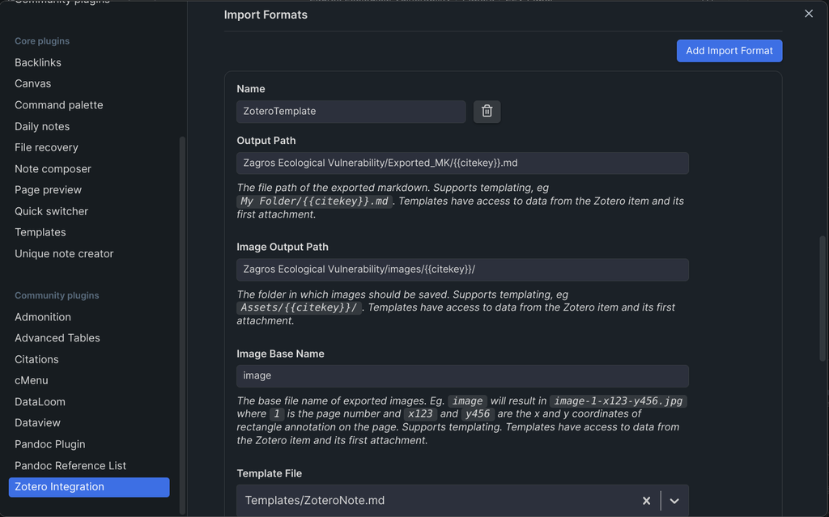

**15-** For importing a note from Zotero, make sure Zotero is open and that you have an annotated article in your library.  
**16-** In Obsidian use the keyboard shortcut Ctrl+P to open the command palette. Search for the name of your import format (“Zotero note” in my case). Press enter. This will open a search bar in Zotero. Search for your article in your library and press enter.  
**17-** For Inserting `References` at the end of your paper set `CitationFormat` and also citation at end of each sentence use the below settings in `Zotero Integration`. Note that you must add two `Citation Format`. First for adding references at the end of the paper called `ZoteroReferernces` and another called `ZoteroCite` that can be used for inserting citations in the context of the paper:

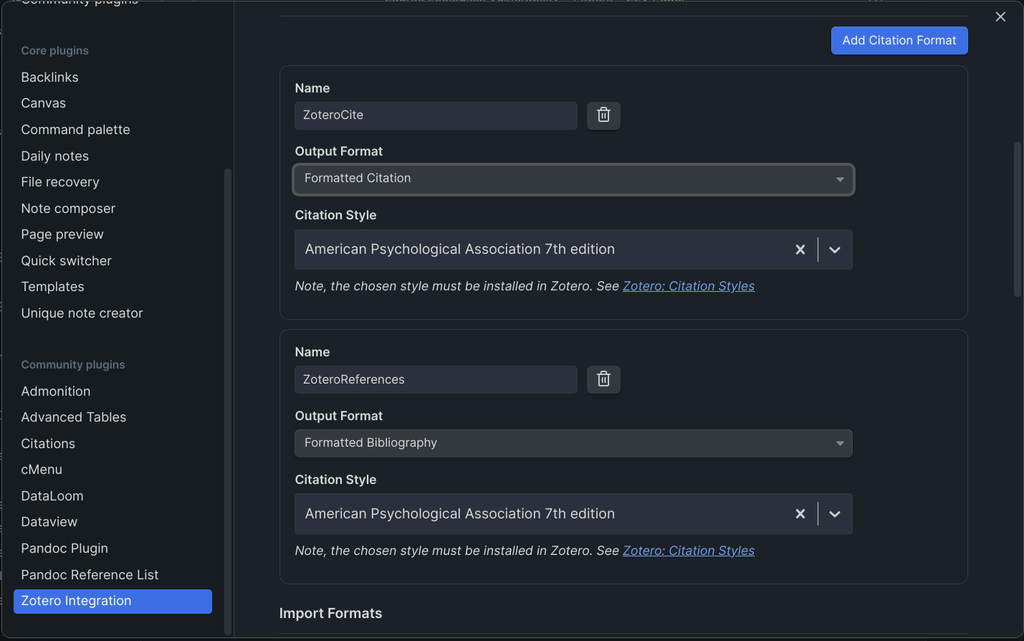

**18-** After importing highlighted context, comment, images and etc. from `Zotero` into `Obsidian`, you can select specific tags with connected text using `Dataview` plugin in Obsidian. So, it is better to convert each `#Tag` in obsidian to `Note`. You can do that as follow:

A- Install `Tag Wrangler` plugin in Obsidian and enable it.  
B- In `#` interface `right click` on a tag and select `Create tag page`.

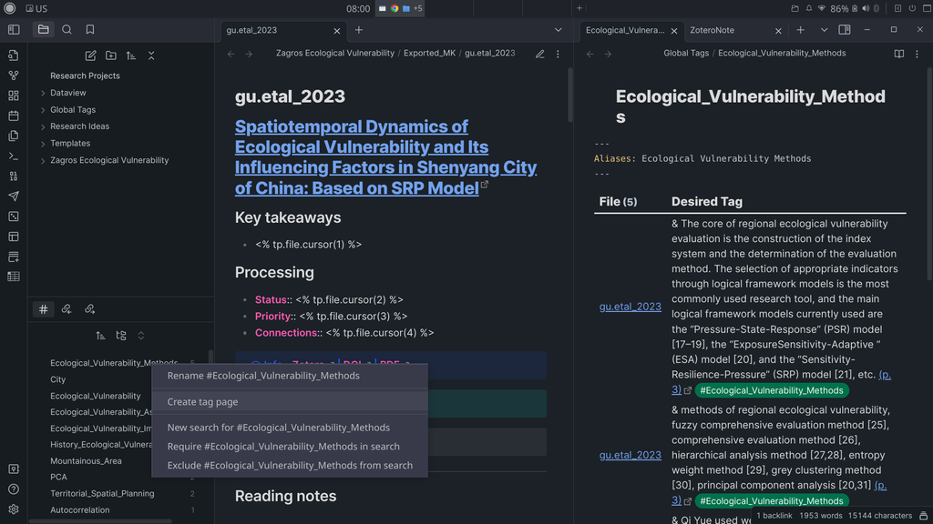

Create Tag Page

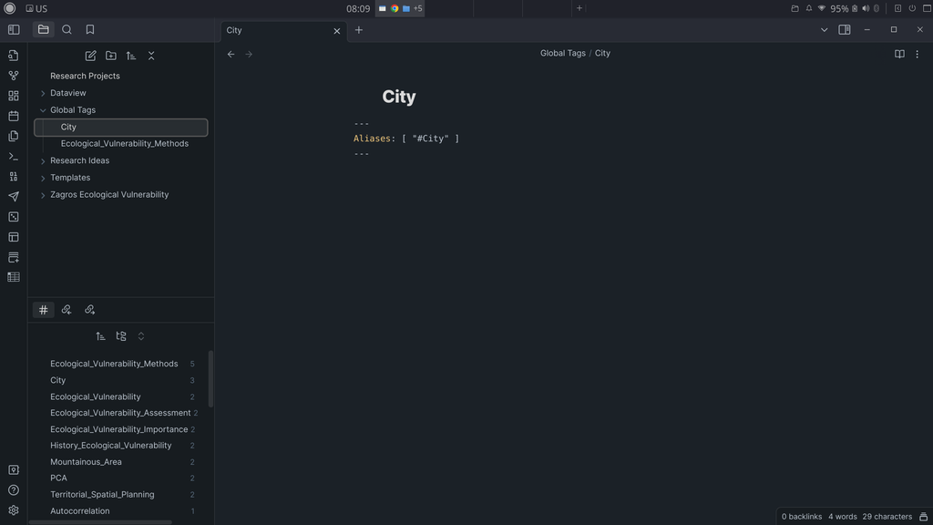

D- For selecting all text with a specific tag name use the below code in opened note file. First remove # in `Aliases` section and then add this code:

````
```dataview
TABLE L.text AS "Desired Tag"
FLATTEN file.lists AS L
WHERE contains(L.tags, this.file.name)
```
````

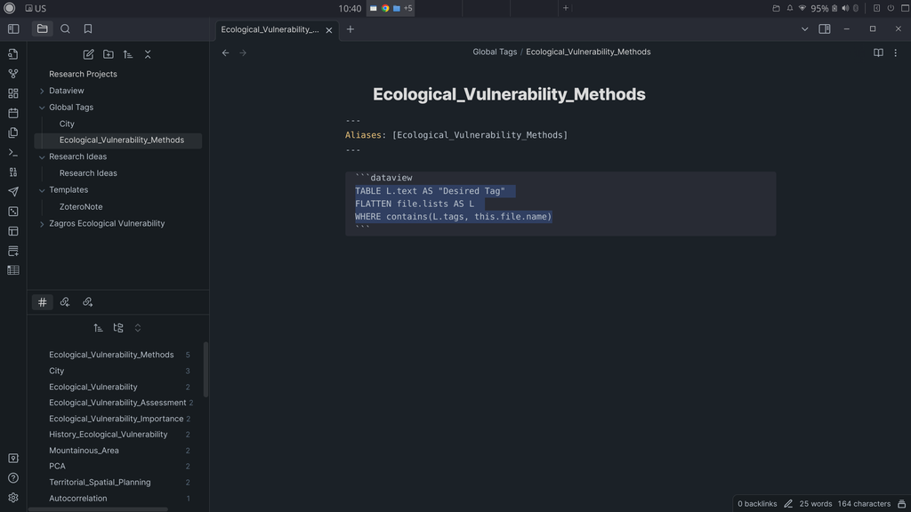

Dataview Filename

For each Note that converted from Tag you can see the below result:

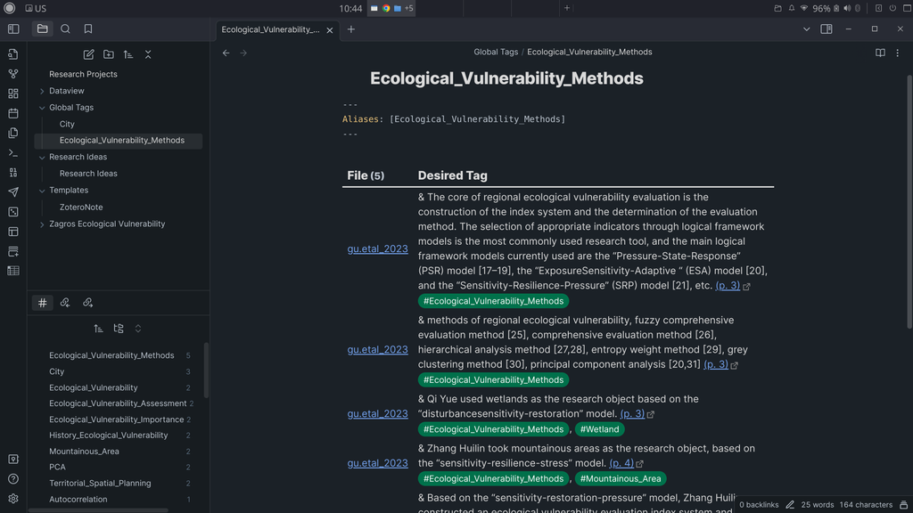

Tag as Note